# From Python to R...(and Gephi)

**Dr. José Manuel MAGALLANES**  
Researcher at Center for Social Complexity, George Mason University (jmagalla@gmu.edu)  
Professor at Department of Social Sciences, Pontificia Universidad Catolica del Peru (jmagallanes@pucp.edu)

If we want to export out work we need to be sure it is clean. So, let's redo the network, this time cleaning all the cells, first identifying if there is any pattern in this dirtiness as we did in a similar R [example](http://rpubs.com/jmagallanes/tutor2):

[figure not shown]

We show below some alternatives to do the cleaning:

[figure not shown]

```python
import networkx as nx
from itertools import combinations
from bs4 import BeautifulSoup as BS
import urllib2
import os
import matplotlib.pyplot as plot
import pandas as pd
%matplotlib inline
import re # library to use regular expressions in Python
```

We will create a function in Python for the cleaning:

```python
def clean_cell(dirtyCellAsString):
    cleanedCell=dirtyCellAsString.replace("million", "000000")
    cleanedCell=cleanedCell.replace(" ", "")
    cleanedCell=cleanedCell.replace(",", "")
    cleanedCell=re.sub(r'[0-9]-|[0-9][0-9]-|[0-9][0-9][0-9]-',"", cleanedCell)
    cleanedCell=re.sub(r'\[[\S ]]',"", cleanedCell)
    cleanedCell=re.findall(r'\d+',cleanedCell)
    return cleanedCell
```

```python
#empty graph RE creation
countriesGraphFullClean=nx.Graph()
```

```python
os.chdir("/Users/josemagallanes/Documents/GITHUBrepositories/Tutorials/TemplatesPython")
openHtml = open("warsList.html","r")
soup = BS(openHtml,'lxml')
openHtml.close()

#getting data for nodes and edges
allTables = soup.findAll('table', {'class': 'sortable wikitable'})
for eachTable in allTables:
        allRows=eachTable.find_all("tr")
        for eachRow in range(1,len(allRows)):
            allCells = allRows[eachRow].find_all("td")

            #start - cleaning
            nameOfConflict=allCells[2].get_text().replace(u'\u2013', '-')
            start=clean_cell(allCells[0].string)
            end=clean_cell(allCells[1].string)
            fatalities=clean_cell(allCells[4].get_text())
            #end - cleaning

            #computing and exceptions
            try:
                duration=2+float(end[0]) - float(start[0])
            except (ValueError,IndexError):
                duration=1
            try:
                fatalities=2+float(fatalities[0])
            except (ValueError,IndexError):
                fatalities=1

            #countries and coordinates from external links
            countries=[country.get_text() for country in allCells[3].find_all('a')]
            countries=['China' if country=="PRC" or country=="People's Republic of China" else country for country in countries]
            linksEachCountry=['http://en.wikipedia.org'+country.get('href') for country in allCells[3].find_all('a')]
            coords=[]
            for link in linksEachCountry:
                if link=='http://en.wikipedia.org/wiki/Soviet_Union':
                    link='http://en.wikipedia.org/wiki/Russia'
                subSoup = BS(urllib2.urlopen(link))
                lati,longi=subSoup.find_all("span",{'class': 'geo'})[0].string.split('; ')
                coords.append((float(lati),float(longi)))
            countryInfo=zip(countries,coords)

            #populating graph
            for country,(lati,longi)in countryInfo:
                countriesGraphFullClean.add_node(country, latitude=lati,longitude=longi)
            for pair in combinations (countries,2):
                countriesGraphFullClean.add_edge(*pair,name=nameOfConflict,duration=duration,fatalities=fatalities)
```

This network data will be saved. No more interaction with the web:

```python
nx.write_graphml(countriesGraphFullClean, "WarsPython.graphml",encoding='utf-8')
```

We call it this way:

```python
countriesNet=nx.read_graphml("WarsPython.graphml")
```

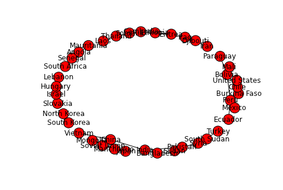

```python
nx.draw(countriesNet)
```

But let's use the coordinates:

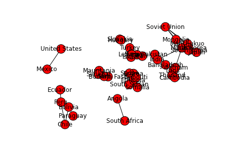

```python
X=nx.get_node_attributes(countriesNet,'longitude')
Y=nx.get_node_attributes(countriesNet,'latitude')
posNet=dict((country,(X[country],Y[country])) for country in X if country in Y)
nx.draw(countriesNet,pos=posNet)
```

I recommend this format for Gephi:

```python
nx.write_gexf(countriesGraphFullClean, "WarsGephi.gexf",encoding='utf-8')
```

Once you are in GEPHI you can export this file for UCINET:

[figure not shown]

And when you are in UCINET you can read the VNA file from Gephi, and create the files you need for plotting and analyzing:

[figure not shown]

Ad of course, from UCINET you can export to **PAJEK** (Networkx is not exporting well into Pajek)

R has many interesting features for Networ analysis, but more important, R has libraries for doing statictical models on networks, which are not available, to my knowledge, in Python - [here](http://socialabstractions.tumblr.com/post/53391947460/exponential-random-graph-models-in-python) is an implementation of network models in Python if you need to go deeper tha R. So if we need to use those libraries, we need to prepare a pair of files for R.

First, the "edgelist" file (including the edge attributes only):

```python
import csv

with open('WarsForR.csv', 'w') as fileEdgeList:
    wr = csv.writer(fileEdgeList , delimiter=',')
    row="from","to","fatalities",'duration','name'
    wr.writerow(row)
    for c1,c2,c1c2Dict in countriesNet.edges(data=True):
        row=c1,c2,c1c2Dict['fatalities'],c1c2Dict['duration'],c1c2Dict['name']
        wr.writerow(row)
```

Finally, the attributes of the nodes will come in this file:

```python
with open('WarsForR_attr.csv', 'w') as fileNodeAttributes:
    wr = csv.writer(fileNodeAttributes, delimiter=',')
    row="country",'longitude','latitude'
    wr.writerow(row)
    for country,countryDict in countriesNet.nodes(data=True):
        row=country,countryDict['longitude'],countryDict['latitude']
        wr.writerow(row)
```

We will go from here to another R [example](http://rpubs.com/jmagallanes/tutor4), to see how to read this network and use the libraries available.